# LDA Summary

Xiaoyang Li

2020/10/28

## Data import

This dataset includes information:

- Demographic info: APPRDX, HISPLAT, race from PPMI_Original_Cohort_BL_to_Year_5_Dataset_Apr2020.csv
- Prime Diagnosis from “./data/Study_Enrollment/Primary_Diagnosis.csv” (Seldom info collected at baseline contain prime diagnosis)
- Olfactory: UPSITBK1, UPSITBK2, UPSITBK3, UPSITBK4 from University_of_Pennsylvania_Smell_ID_Test.csv which means olfactory score from 4 booklet
- Moca: all related variables from Montreal_Cognitive_Assessment_*MoCA*.csv
- Motor: All related variables from MDS_UPDRS_Part_I.csv, MDS_UPDRS_Part_I__Patient_Questionnaire.csv, MDS_UPDRS_Part_II__Patient_Questionnaire.csv, MDS_UPDRS_Part_III.csv, MDS_UPDRS_Part_IV.csv
- Stai: all related variables from State-Trait_Anxiety_Inventory.csv

```r
data = read_csv("./data/Clean_Join.csv")
BL = data %>% filter(EVENT_ID == "BL") %>% select(PATNO, EVENT_ID,everything())
```

## LDA (method = “VEM”)

### Prepare DocumentTermMatrix for LDA

```r
BL = BL %>% select(PATNO, EVENT_ID, everything()) %>%
  pivot_longer(APPRDX:mctot, names_to = "Variable", values_to = "word") %>%
  filter(is.na(word) == FALSE)

BLcount = BL %>% group_by(PATNO,word) %>% count()

BLdtm = BLcount %>% cast_dtm(PATNO, word, n)
```

### Find suitable k (Topics number)

```r
ldas = c()
topics = c(2,3,4,5,6,8,10)
for(topic in topics){
   start_time = Sys.time()
   lda = LDA(BLdtm, k = topic, control = list(seed = 2020))
   ldas = c(ldas,lda)
   print(paste(topic ,paste("topic(s) and use time is ", Sys.time() -start_time)))
   save(ldas,file = "ldas_result")
}
```

```
## [1] "2 topic(s) and use time is  1.34200310707092"
## [1] "3 topic(s) and use time is  2.34681606292725"
## [1] "4 topic(s) and use time is  3.7344491481781"
## [1] "5 topic(s) and use time is  5.17016887664795"
## [1] "6 topic(s) and use time is  6.47828793525696"
## [1] "8 topic(s) and use time is  9.27571296691895"
## [1] "10 topic(s) and use time is  12.4326150417328"
```

```r
load("ldas_result")
```

Here I use topic numbers as 2,3,4,5,6,8,10 separately.

Firstly, I compare their Perplexity.

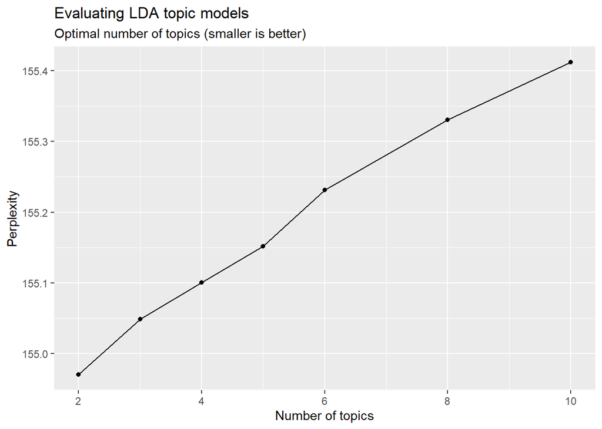

```r
perplexity = data_frame(k = topics,
           perplex = map_dbl(ldas, topicmodels::perplexity))
perplexity %>%
  ggplot(aes(k, perplex)) +
  geom_point() +
  geom_line() +
  labs(title = "Evaluating LDA topic models",
       subtitle = "Optimal number of topics (smaller is better)",
       x = "Number of topics",
       y = "Perplexity")
```

We always prefer the topic model with small Perplexity. However, the result in this case is a little weird. In most cases, when the number of topics increase, the perplexity of corresponding model tend to decrease. Therefore, I use another package `ldatuning` to find the best topic numbers.

```r
# LDA tuning
LDAtune = FindTopicsNumber(
  BLdtm,
  topics = topics,
  metrics = c("CaoJuan2009", "Arun2010", "Deveaud2014"),
  method = "VEM",
  control = list(seed = 2020),
  mc.cores = 2L,
  verbose = TRUE
)
```

```
## fit models... done.
## calculate metrics:
##   CaoJuan2009... done.
##   Arun2010... done.
##   Deveaud2014... done.
```

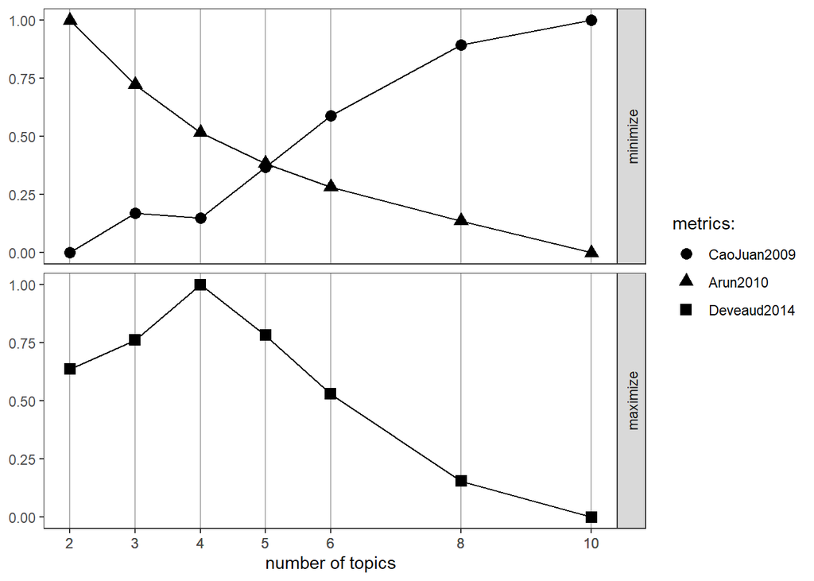

```r
FindTopicsNumber_plot(LDAtune)
```

This package offer 3 metrics to evaluate lda obtained from “VEM”. For “CaoJuan2009” and “Arun2010”, we prefer smaller score. For “Deveaud2014”, we prefer larger score. Considering comprehensively, I choose topic numbers = 3, 4, 5 to visualize

```r
BLlda3 = LDA(BLdtm, k = 3, control = list(seed = 2020))
BLlda4 = LDA(BLdtm, k = 4, control = list(seed = 2020))
BLlda5 = LDA(BLdtm, k = 5, control = list(seed = 2020))
```

By using `LDAvis`, I create 3 interactive plot to show the topic model result.

```r
# prepare to produce json
topicmodels_json_ldavis = function(fitted, doc_term){
  require(LDAvis)
  require(slam)

  ls_LDA = function (phi)
  {
    jensenShannon <- function(x, y) {
      m <- 0.5 * (x + y)
      lhs <- ifelse(x == 0, 0, x * (log(x) - log(m+1e-16)))
      rhs <- ifelse(y == 0, 0, y * (log(y) - log(m+1e-16)))
      0.5 * sum(lhs) + 0.5 * sum(rhs)
    }
    dist.mat <- proxy::dist(x = phi, method = jensenShannon)
    pca.fit <- stats::cmdscale(dist.mat, k = 2)
    data.frame(x = pca.fit[, 1], y = pca.fit[, 2])
  }

  # Find required quantities
  phi <- as.matrix(posterior(fitted)$terms)
  theta <- as.matrix(posterior(fitted)$topics)
  vocab <- colnames(phi)
  term_freq <- slam::col_sums(doc_term)

  # Convert to json
  json_lda <- LDAvis::createJSON(phi = phi, theta = theta,
                                 vocab = vocab,
                                 doc.length = as.vector(table(doc_term$i)),
                                 term.frequency = term_freq, mds.method = ls_LDA)

  return(json_lda)
}


json3 = topicmodels_json_ldavis(BLlda3,BLdtm)
json4 = topicmodels_json_ldavis(BLlda4,BLdtm)
json5 = topicmodels_json_ldavis(BLlda5,BLdtm)

serVis(json3,open.browser = T)
serVis(json4,open.browser = T)
serVis(json5,open.browser = T)
```

http://127.0.0.1:3454/ LDA model with 3 topics

http://127.0.0.1:3685/ LDA model with 4 topics

http://127.0.0.1:4768/ LDA model with 5 topics

I choose topics number = 3

### k = 3 (BLlda3)

Word-topic probabilities (per-topic-per-word probabilities)

```r
topics = tidy(BLlda3, matrix = "beta")
topics
```

| topic | term | beta |
| --- | --- | --- |
| 1 | booklet1_1 | 7.563778e-03 |
| 2 | booklet1_1 | 8.850212e-04 |
| 3 | booklet1_1 | 1.109844e-02 |
| 1 | booklet2_1 | 5.874063e-03 |
| 2 | booklet2_1 | 6.928173e-03 |
| 3 | booklet2_1 | 7.858005e-03 |
| 1 | booklet3_1 | 4.626389e-03 |
| 2 | booklet3_1 | 2.396821e-03 |
| 3 | booklet3_1 | 1.188393e-02 |
| 1 | booklet4_1 | 7.892631e-03 |

[output cut: 803 more lines]

```r
topics %>% filter(
  term == "HC" | term == "PD" |term == "SWEDD"
) %>% arrange(topic)
```

| topic | term | beta |
| --- | --- | --- |
| 1 | HC | 0.0010612671 |
| 1 | PD | 0.0011226745 |
| 1 | SWEDD | 0.0003154244 |
| 2 | HC | 0.0008524961 |
| 2 | PD | 0.0026713260 |
| 2 | SWEDD | 0.0001384598 |
| 3 | HC | 0.0008131247 |
| 3 | PD | 0.0020910205 |
| 3 | SWEDD | 0.0004365240 |

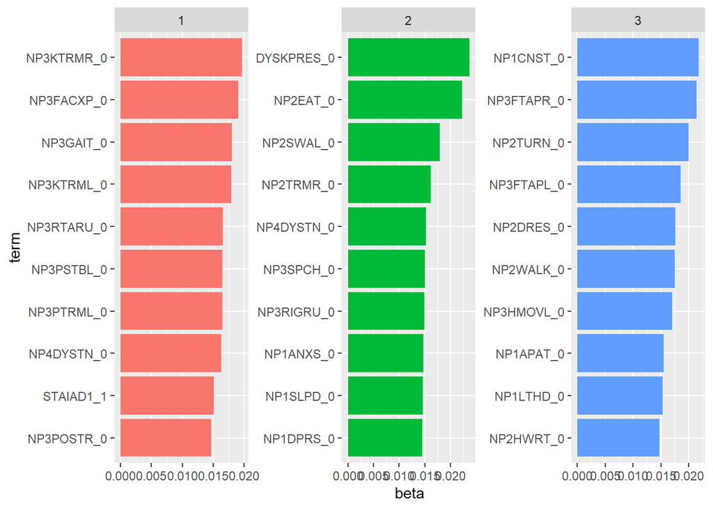

```r
# top terms
top_term = topics %>%
  group_by(topic) %>%
  top_n(10, beta) %>%
  ungroup() %>%
  arrange(topic, -beta)

top_term %>%
  mutate(term = reorder_within(term, beta, topic)) %>%
  ggplot(aes(term, beta, fill = factor(topic))) +
  geom_col(show.legend = FALSE) +
  facet_wrap(~topic, scales = "free") +
  coord_flip() +
  scale_x_reordered()
```

Code dictionary

| Topic1 | Code | Meaning |
| --- | --- | --- |
| 1 | NP3KTRMR_0 | Kinetic tremor - Right hand 0-2 |
| 2 | NP3FACXP_0 | Facial expression 0-2 |
| 3 | NP3GAIT_0 | Gait 0-2 |
| 4 | NP3KTRML_0 | Kinetic tremor - Left hand 0-2 |
| 5 | NP3RTARU_0 | Rest tremor amplitude - RUE 0-2 |
| 6 | NP3PSTBL_0 | Postural stability 0-2 |
| 7 | NP3PTRML_0 | Postural tremor - Left hand 0-2 |
| 8 | NP4DYSTN_0 | Painful OFF-state dystonia 0-2 |
| 9 | STAIAD1_1 | STAI Question 1 3-4 |
| 10 | NP3POSTR_0 | Posture 0-2 |

| Topic2 | Code | Meaning |
| --- | --- | --- |
| 1 | DYSKPRES_0 | Were dyskinesias present 0 |
| 2 | NP2EAT_0 | EATING TASKS 0-2 |
| 3 | NP2SWAL_0 | CHEWING AND SWALLOWING 0-2 |
| 4 | NP2TRMR_0 | TREMOR 0-2 |
| 5 | NP4DYSTN_0 | Painful OFF-state dystonia 0-2 |
| 6 | NP3SPCH_0 | Speech |
| 7 | NP3RIGRU_0 | Rigidity - RUE 0-2 |
| 8 | NP1ANXS_0 | ANXIOUS MOOD 0-2 |
| 9 | NP1SLPD_0 | DAYTIME SLEEPINESS 0-2 |
| 10 | NP1DPRS_0 | DEPRESSED MOODS 0-2 |

| Topic3 | Code | Meaning |
| --- | --- | --- |
| 1 | NP1CNST_0 | CONSTIPATION PROBLEMS 0-2 |
| 2 | NP3FTAPR_0 | Finger Tapping Right Hand 0-2 |
| 3 | NP2TURN_0 | TURNING IN BED 0-2 |
| 4 | NP3FTAPL_0 | Finger Tapping Left Hand 0-2 |
| 5 | NP2DRES_0 | DRESSING 0-2 |
| 6 | NP2WALK_0 | WALKING AND BALANCE 0-2 |
| 7 | NP3HMOVL_0 | Hand movements - Left Hand 0-2 |
| 8 | NP1APAT_0 | APATHY 0-2 |
| 9 | NP1LTHD_0 | LIGHTHEADEDNESS ON STANDING 0-2 |
| 10 | NP2HWRT_0 | HANDWRITING 0-2 |

Document-topic probabilities (per-document-per-topic probabilities)

```r
docu = tidy(BLlda3, matrix = "gamma")
docu %>% arrange(desc(gamma))
```

| document | topic | gamma |
| --- | --- | --- |
| 41400 | 1 | 0.3450897 |
| 42379 | 1 | 0.3433521 |
| 58783 | 3 | 0.3431861 |
| 52552 | 1 | 0.3428095 |
| 71809 | 3 | 0.3427541 |
| 58420 | 1 | 0.3419955 |
| 40744 | 3 | 0.3414943 |
| 51914 | 3 | 0.3414073 |
| 41410 | 3 | 0.3410584 |
| 40755 | 1 | 0.3409697 |

[output cut: 5786 more lines]